# Exploring Caribbean Maps in R

The Struggle Is Real

Author

Martina Regis

Published

April 2025

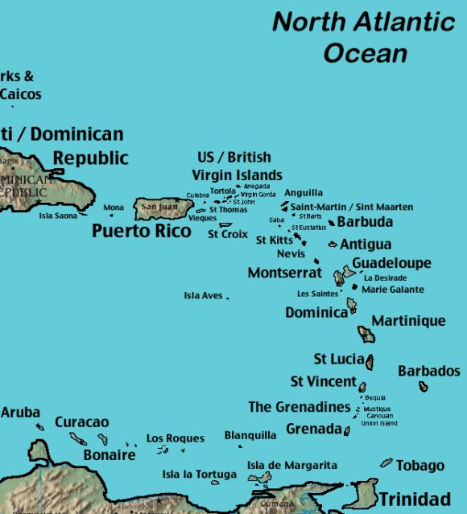

Photo credit: Scuba Diving

# Mapping

For what feels like an eternity, I have been wrestling with trying to visualize the Caribbean through maps in Posit - that is, capturing accurate and aesthetically-pleasing maps, with a particular focus on the member states of the Eastern Caribbean Currency Union (ECCU). My hard drive has been a graveyard of failed attempts, each map dissolving into a mess of mismatched coastlines, misplaced islands - just not capturing the eight islands as I would like.

Countless packages and countless lines of code have been deployed in this quest, yet the desired level of detail and regional specificity consistently eluded me, leaving me navigating a sea of geospatial data with limited success.

This blog post serves as a chronicle of that very struggle, a testament to the often-underappreciated intricacies of digital cartography, especially when dealing with smaller island nations. Within these digital pages, I aim to share the winding path I finally traversed to achieve a representation of the ECCU that, while not yet flawless, marks a significant step forward from my previous endeavors. It is my hope that by detailing the trials, the errors, and ultimately the partial triumphs of this mapping journey, others embarking on similar geospatial visualizations might find some practical guidance and perhaps even a bit of solace in knowing they are not alone in the occasional frustrations of rendering our beautiful, complex Caribbean islands.

## Attempts Along the Way

The following charts and maps represent some very rough initial attempts at visualizing the regon. Frankly, most of them fall short of being truly presentable. I would strongly caution against these initial ones. However, the last option displayed shows some potential and represents a more suitable foundation for future improvements.

## Option 1

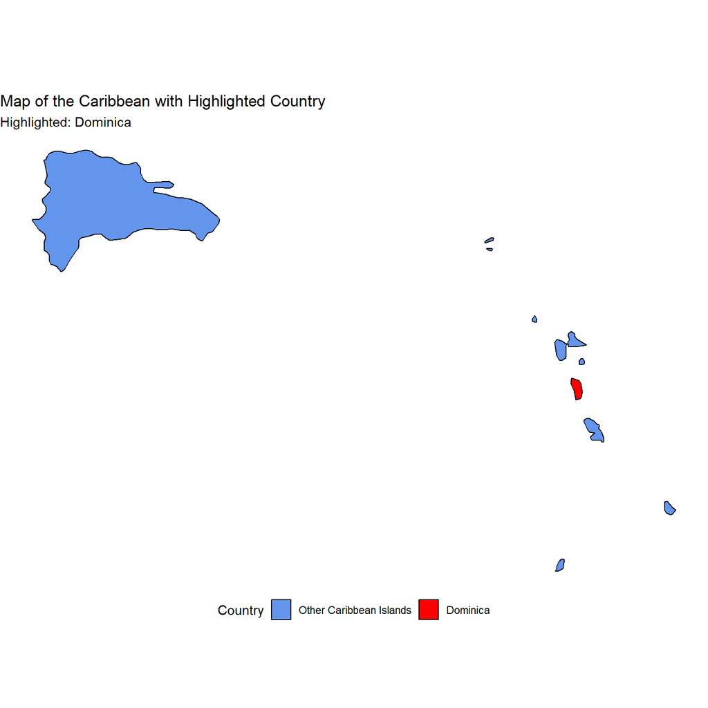

# Option 2

Another option in the iterative process. Not quite suitable.

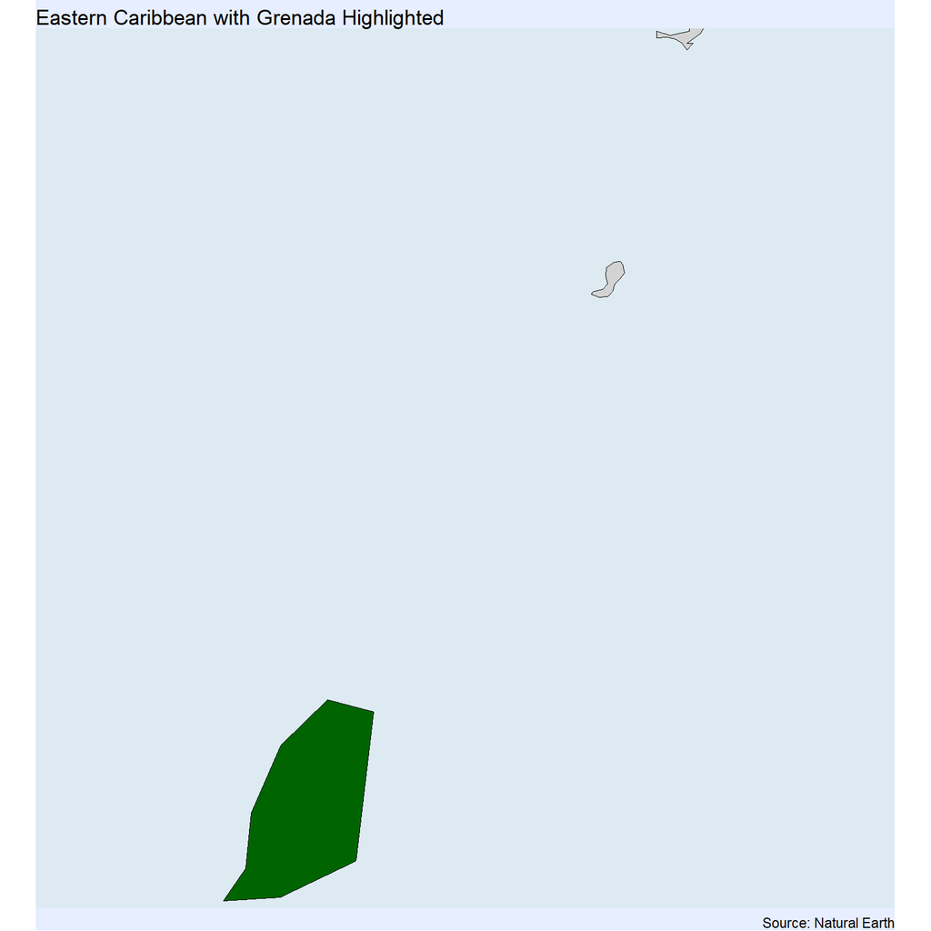

# Option 3

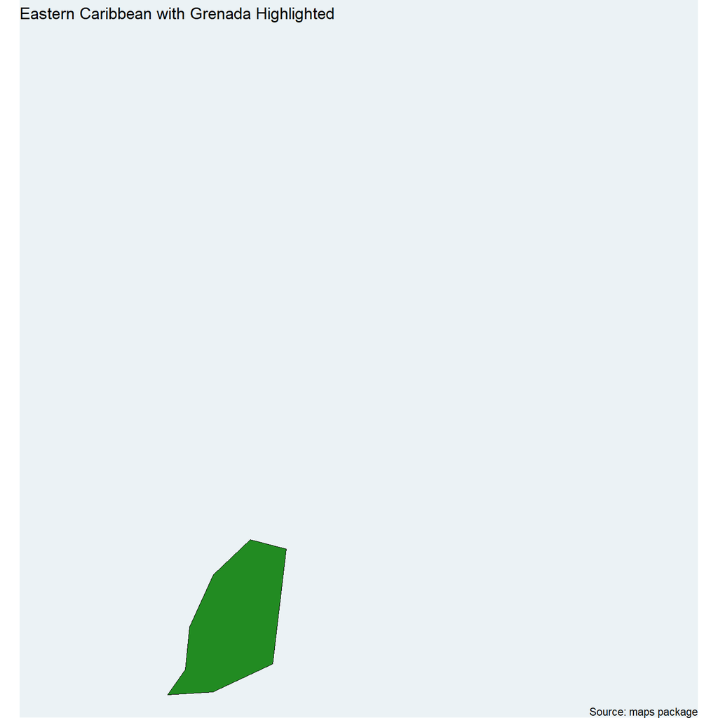

# Option 4

While the current map of the ECCU region isn’t yet the flawless cartographic representation I envision, it stands as the most aesthetically pleasing and geographically coherent output achieved after months of persistent effort. Although minor imperfections remain, particularly concerning the precise sizing of individual islands and the unintentional inclusion of mainland territory to the south, the overall visual balance and regional depiction are a significant improvement over previous attempts. For the immediate purposes of this analysis, this rendition offers a satisfactory visual context, and I intend to proceed with its inclusion. The pursuit of absolute perfection in its detail continues as an ongoing endeavor, with further refinements planned to address the remaining nuances in map size that could fit a wider frame.

If you have any tips, please share with me!

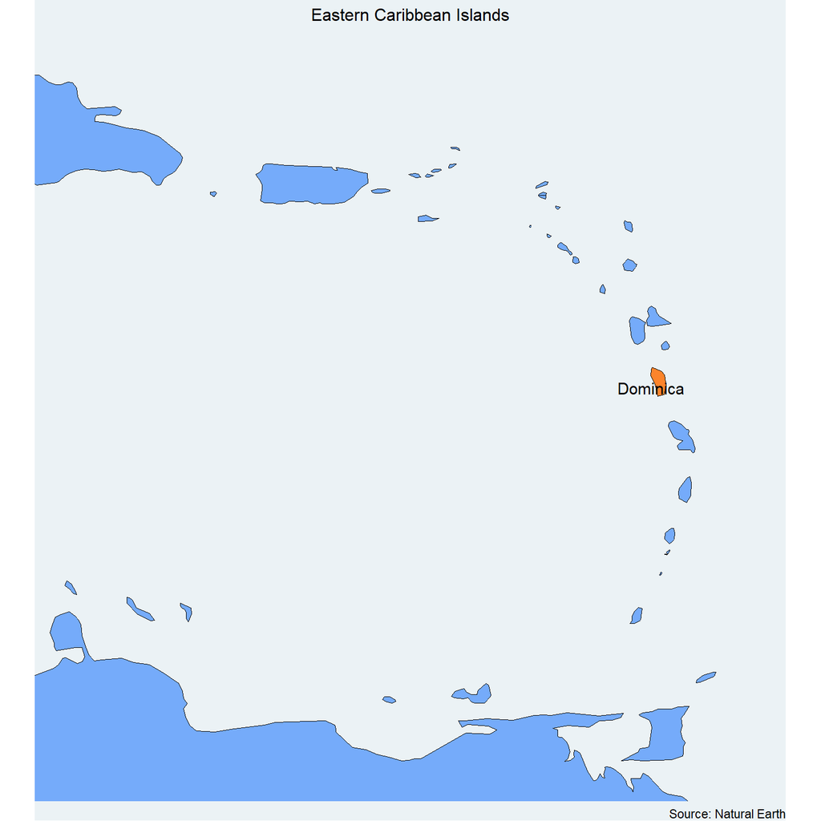